# LAD calibration

Nathéo BEAUCHAMP

2025-09-24

# Motivation of the study

This study aims to calibrate Leaf Area Density (LAD), which is defined as the area of leaves per unit of tree crown volume (in $m^2.m^{-3}$). This parameter forms the basis of numerous process-based forest models, such as physiological models that consider photosynthesis and transpiration (e.g. SurEau by Cochard et al., 2021), and forest gap models that estimate light interception (e.g. ForCEEPS by Morin et al., 2021, and Samsara2 by Courbaud et al., 2015).

Although the leaf area density can be directly estimated from a sample of trees (Stadt & Lieffers, 2000), this method is laborious and difficult to replicate for every tree in a stand. Therefore, indirect methods can be employed, such as model inversion using a hemispherical photograph (Courbaud et al., 2003) or the more recent LiDAR methodology (Wei et al., 2020). However, there is a significant lack of research on LAD in the scientific literature, as there are no large-scale databases containing values for a wide range of European species. Furthermore, the few reported species-specific values vary considerably between studies (Ligot et al., 2014).

The aim of this study is to estimate leaf area density (LAD) for angiosperms and gymnosperms, considering eight main species: Fagus sylvatica, Picea abies, Quercus sp., Carpinus betulus, Pseudotsuga menziesii, Pinus sylvestris, Abies alba, Larix decidua with ‘other species’ (especially angiosperms). Additionally, Nock et al. (2008) demonstrated intraspecific variation in LAD, with intracrown leaf area decreasing by up to 40% with increasing tree age. This led us to consider the effect of diameter as well. Finally, as crown dimensions are very sensitive to local competition (Touzot et al., 2025), we hypothesise that LAD may also vary in response to competition.

# Methodology

In this study, we used a model inversion methodology, using the ray-tracing model SamsaraLight (Courbaud et al. 2003). We want to estimate the SamsaraLight tree-level parameter LAD using measurements of transmitted light $PACL_{obs}$ (for percentage of above light canopy), based on hemispherical photographs, within 45 plots of different composition and structures. For each plot, trees are inventoried with their crown dimensions, allowing to derive an estimated transmitted light $PACL_{est}$ on virtual sensors with the ray-tracing model SamsaraLight. By doing so, for each virtual sensor of each plot, we have the observed transmitted light $PACL_{obs}$, and the estimated transmitted light given a tree-level value of LAD $PACL_{est}$.

For this study, we used the SamsaraLight model with the R package SamsaraLight (Beauchamp et al., work in progress, intended for publication in the Journal of Open Source Software). The SamsaraLight model was initially developed in Java and included in the Capsis simulation platform (SamsaraLightLoader by Gauthier Ligot). It could be called from R software via the “RCapsis” R package (Fortin et al., 2021). To speed up calculation times and make SamsaraLight easier to use in an R environment, we created the “SamsaraLight” R package. The source code is written in C++ to enable fast calculations and communication with the R environment is handled by the Rcpp package (Eddelbuettel & Balamuta, 2018). The “SamsaRaLight” R package reduces calculation time compared to the previous method (the RCapsis R package calling the Java model SamsaRaLightLoader) as it does not require the creation of a Java server nor Java objects. It also facilitates the use of SamsaraLight within R, as it does not require the creation of an inventory file, instead using R objects and functions directly. The package is functional and stored in a GitHub repository, but it is still subject to private restrictions as discussions regarding co-authorship and the intellectual property rights of the source code need to be concluded.

# Preliminary analysis

As a preliminary analysis, we tried to fit a mean LAD value for each sensor of each site. To do so, we run the SamsaraLight model on each stand by fixing the same crown LAD values of each tree, and for each sensor, we computed the residuals between the estimated PACL value on the virtual sensor, and the observed PACL on the field for this sensor. We did so for 500 values of LAD from 0.01 to 5. By doing so, we could find for each sensor the LAD that minimizes the residuals.

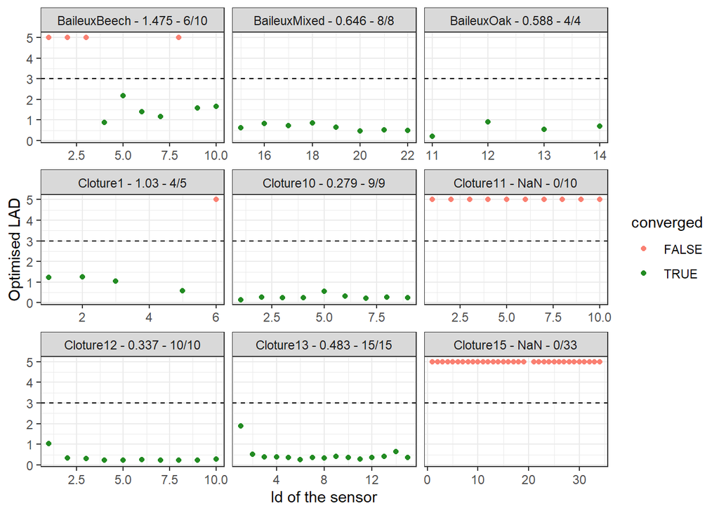

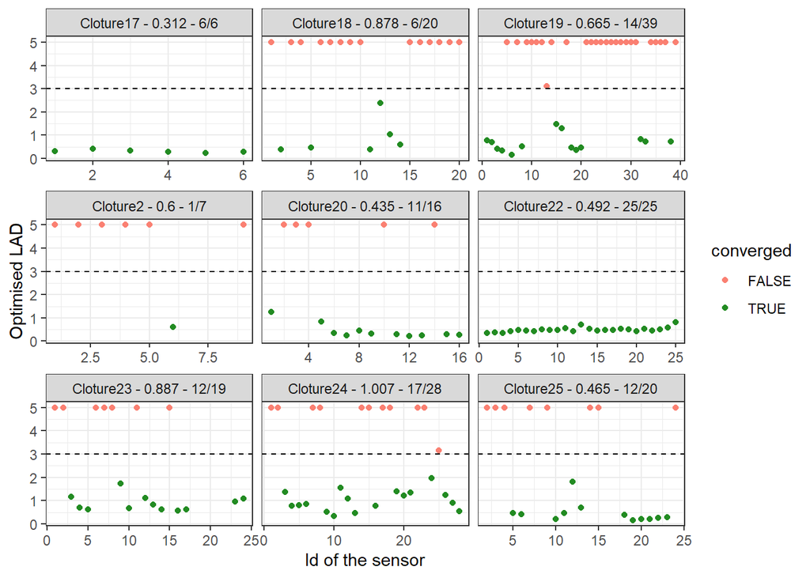

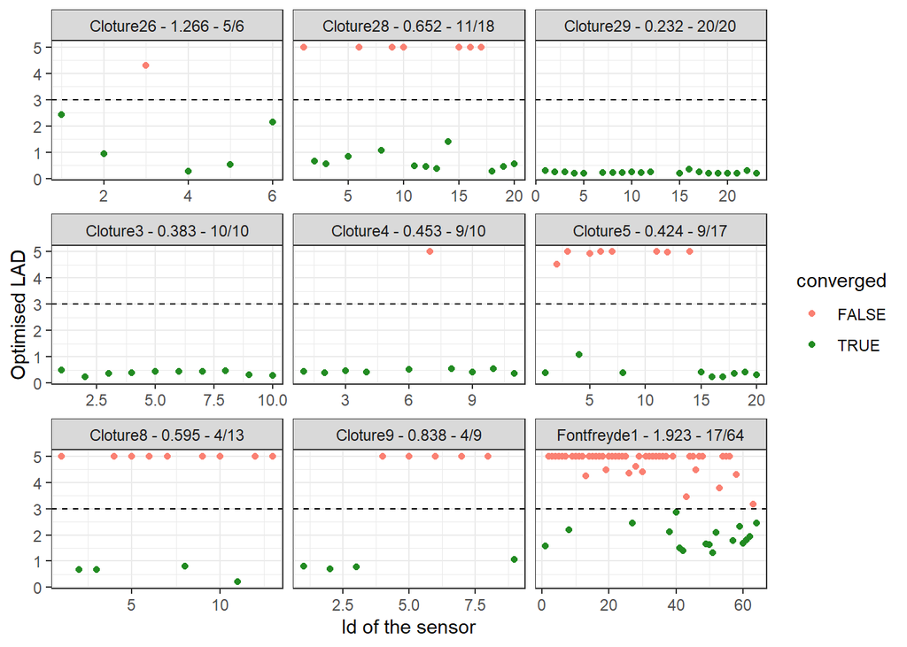

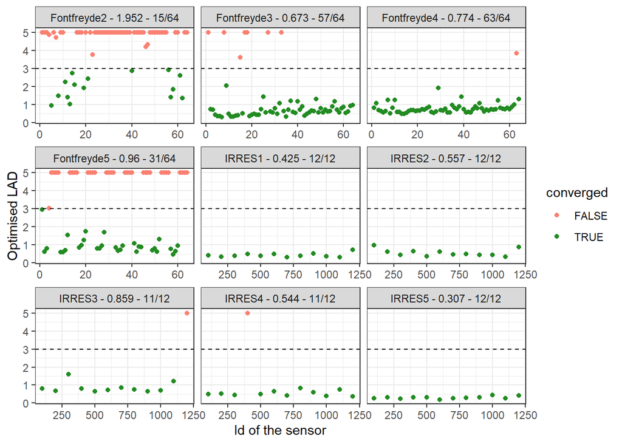

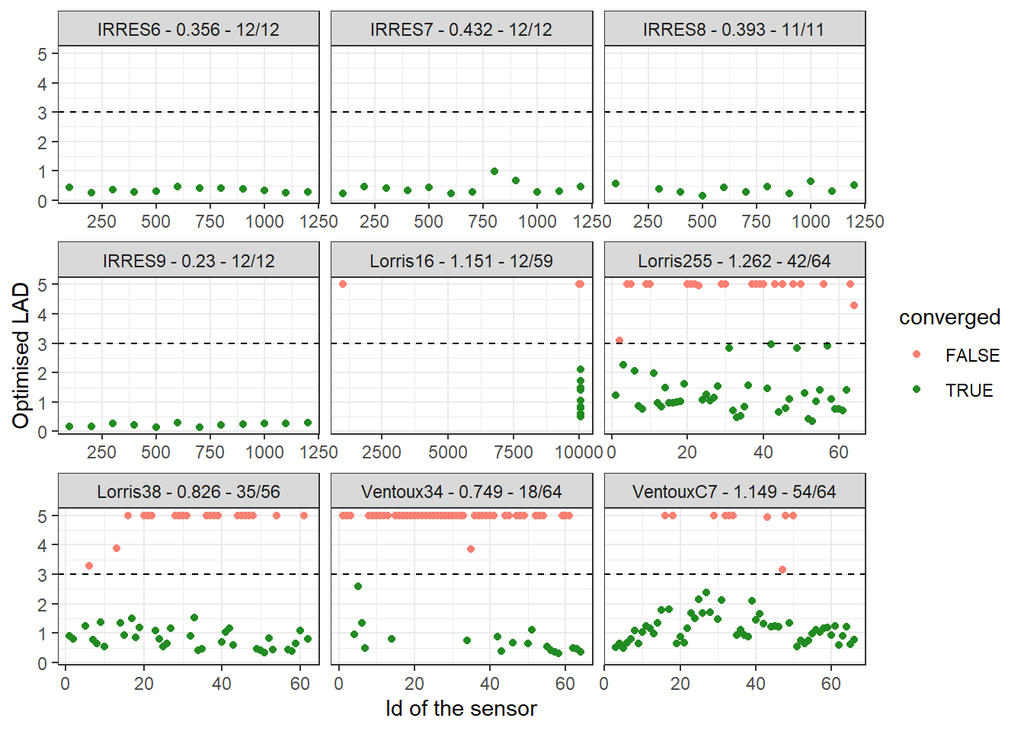

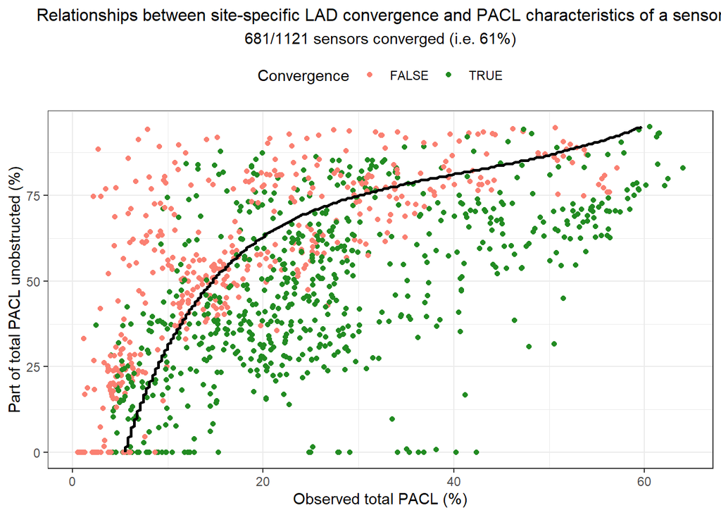

The mean LAD over all sensors that converged was about 0.785

# Bayesian calibration

50,000 iterations (20,000 burning), 5 chain, for BATOTxDBH model angio/gymno

## Model sigmas

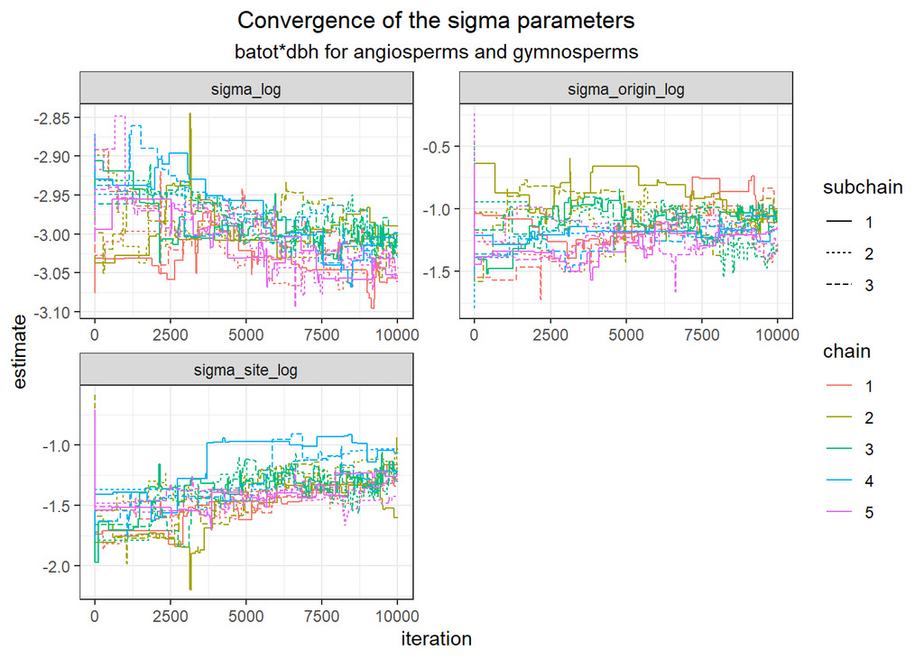

## Model for angiosperm

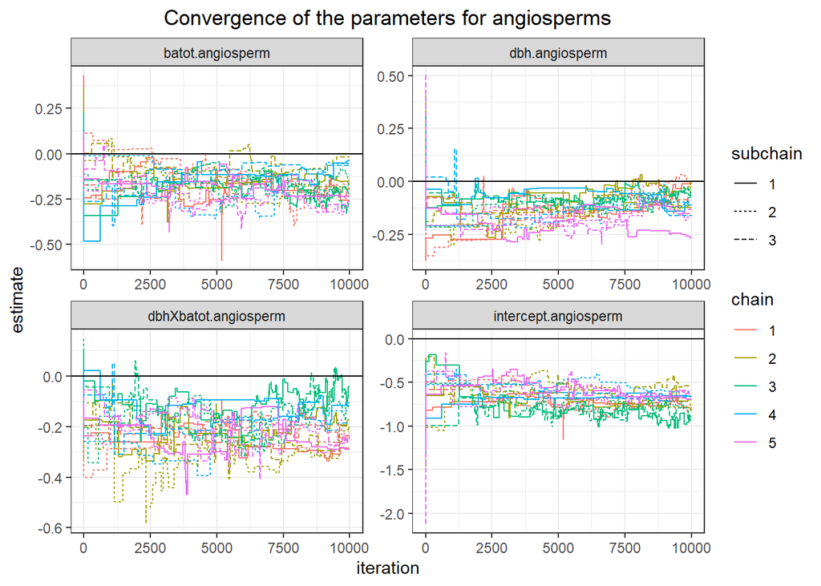

## Model for gymnosperm

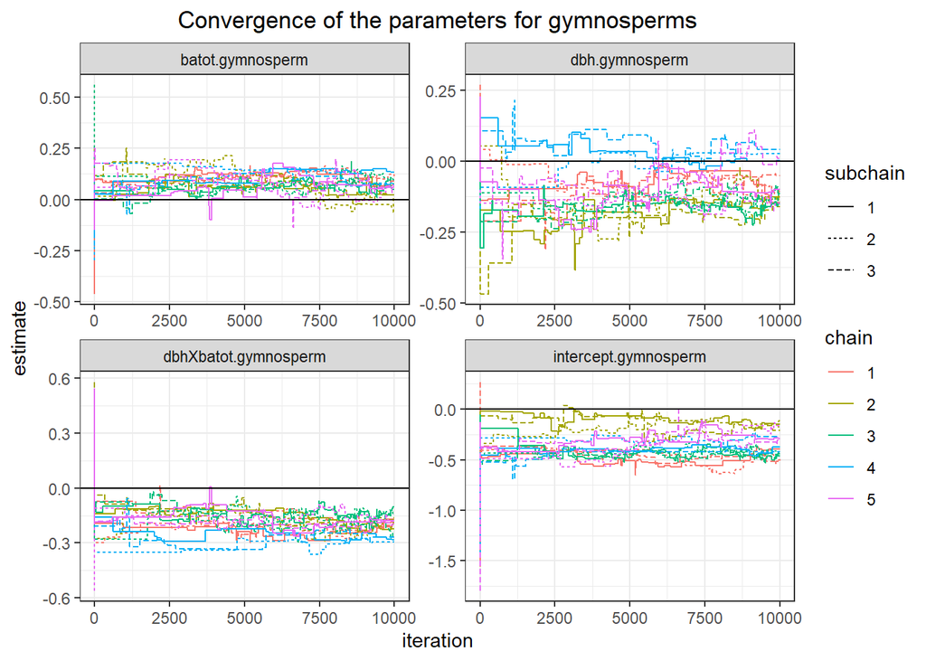

# Main analysis

## LAD predictions from model calibration

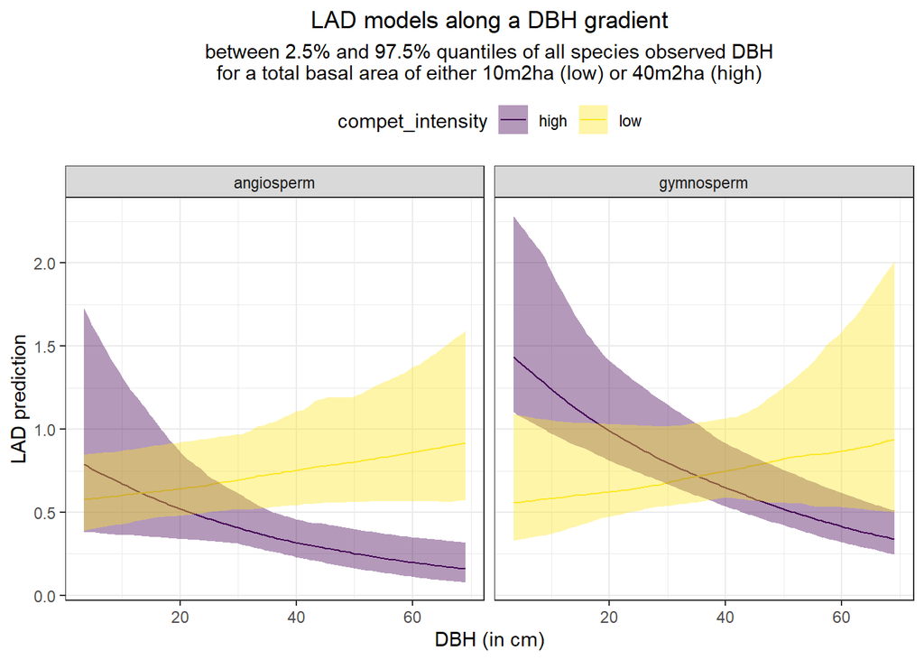

## Estimate LAD on initial data

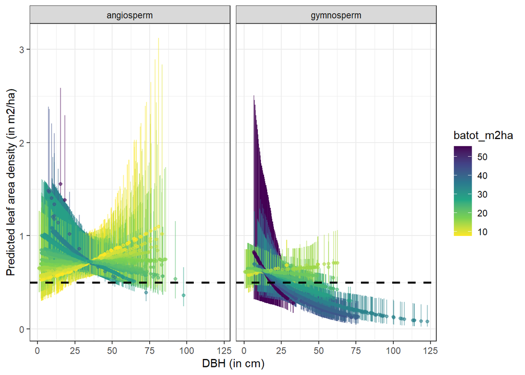

## Link predicted LAD to observed tree crown volume

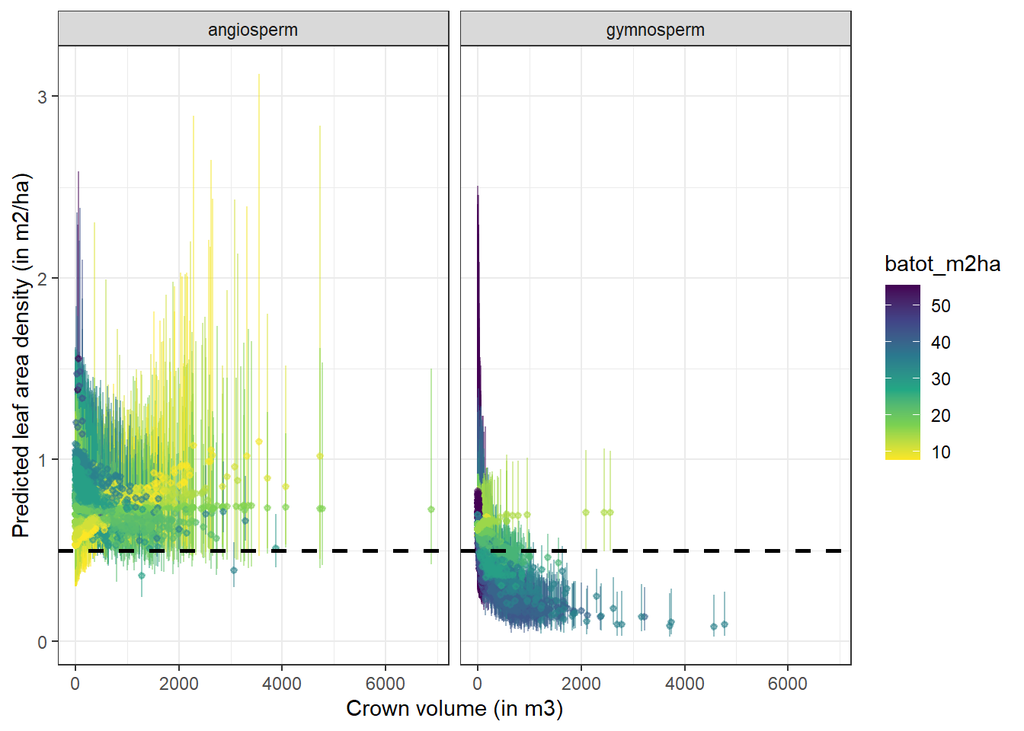

## Tree-level consequences on total leaf area LA

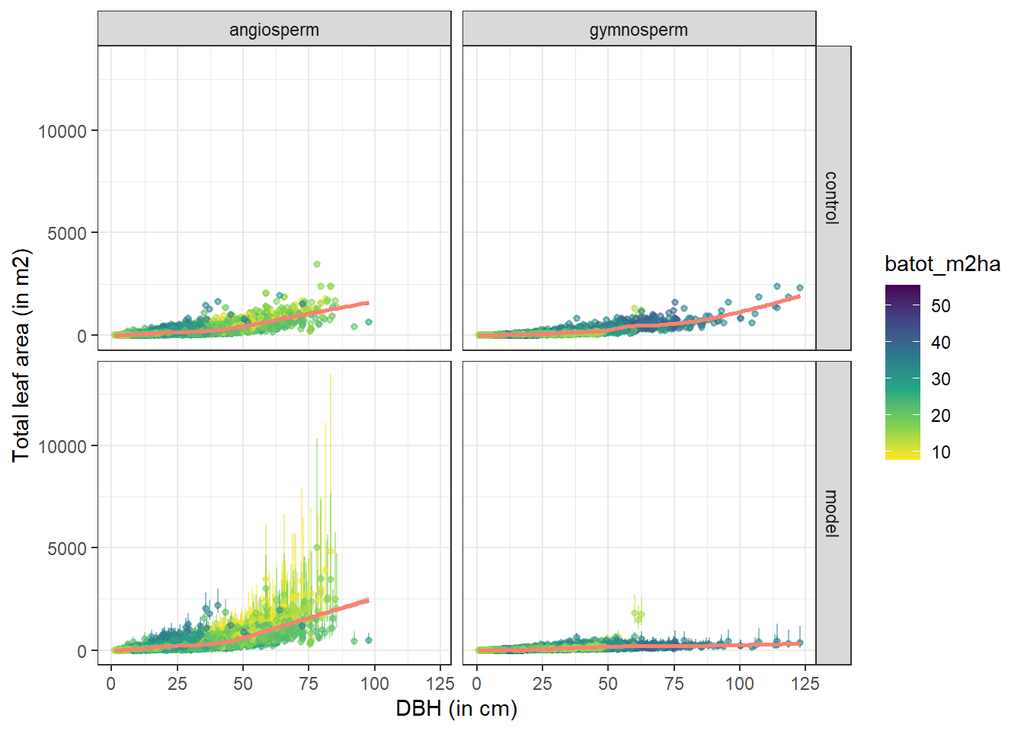

## Stand-level consequences on leaf area index LAI

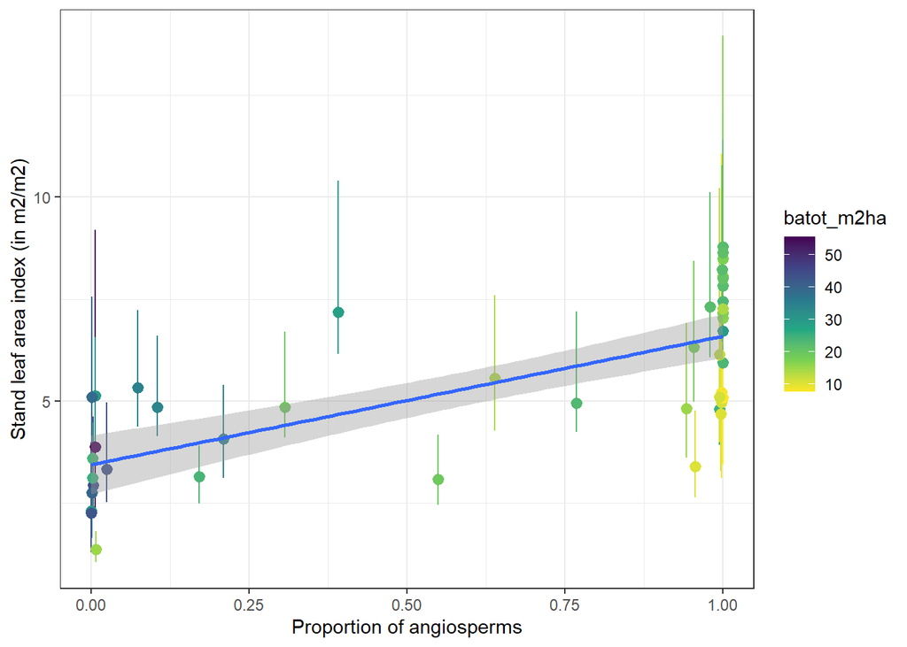

## Stand-level comparison with control model

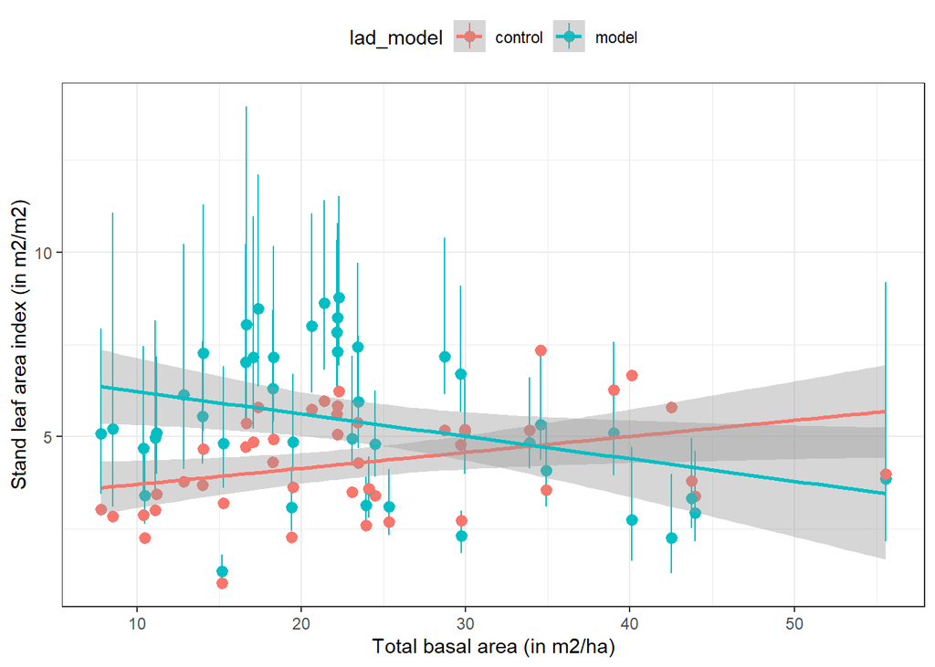

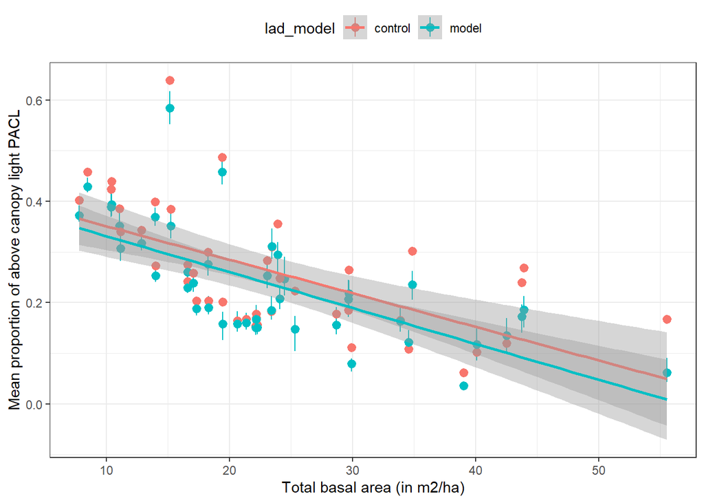

# Appendix

## Basal area vs. compo

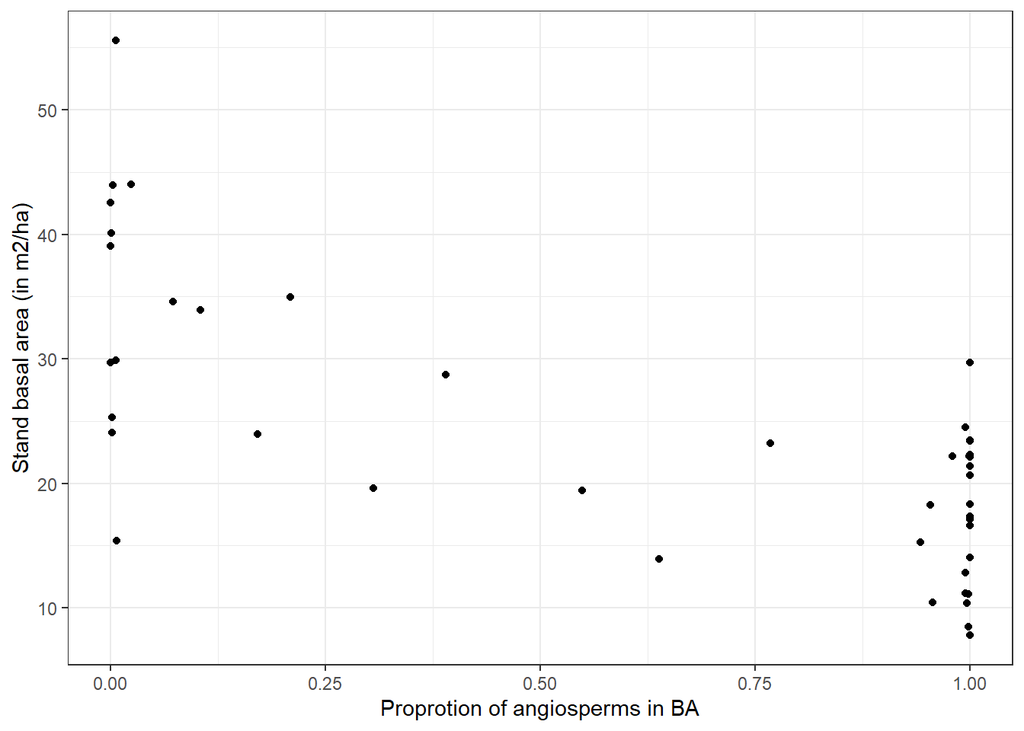

## Basal area vs. DBH

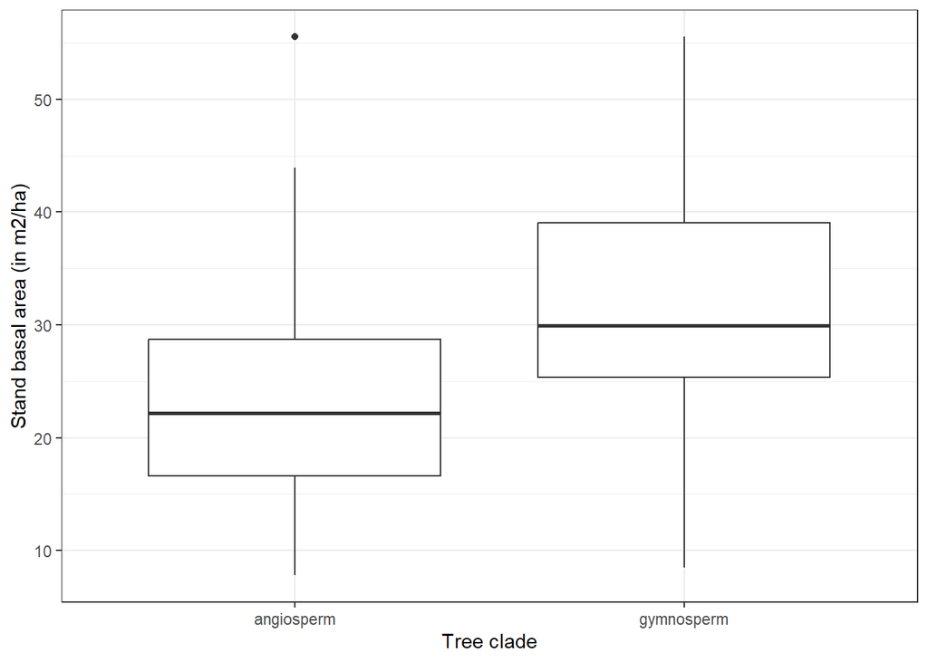

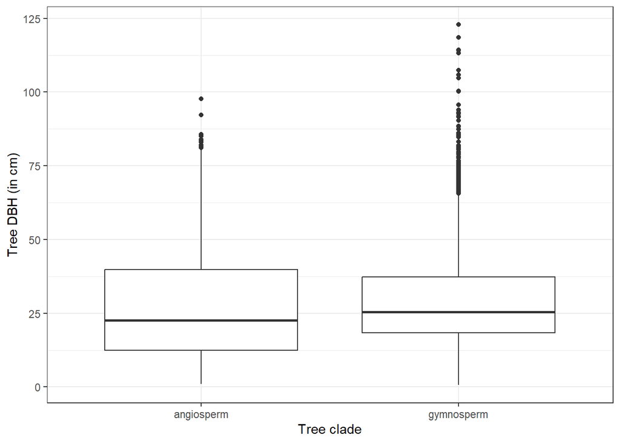

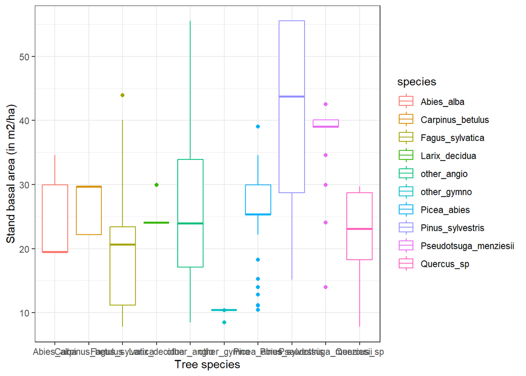

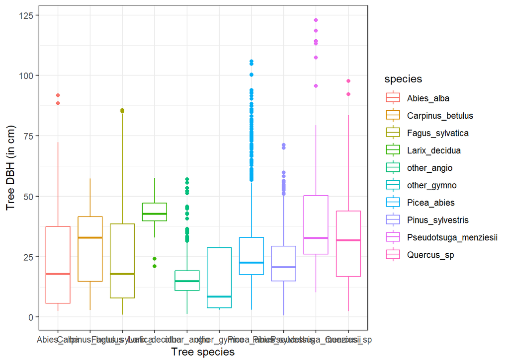

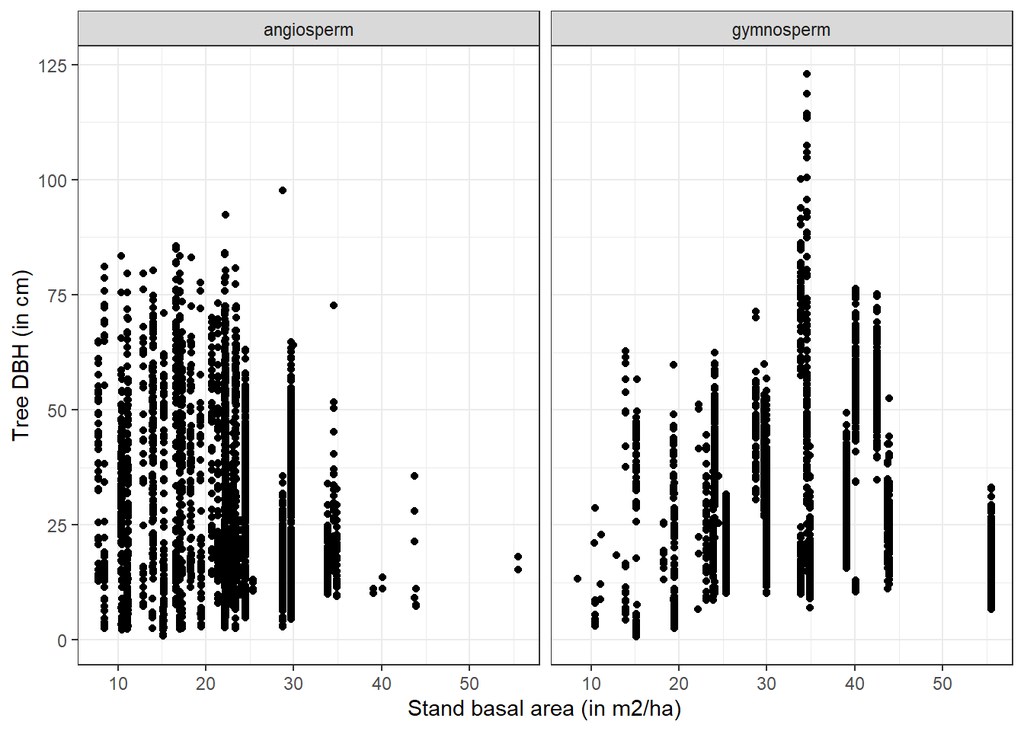

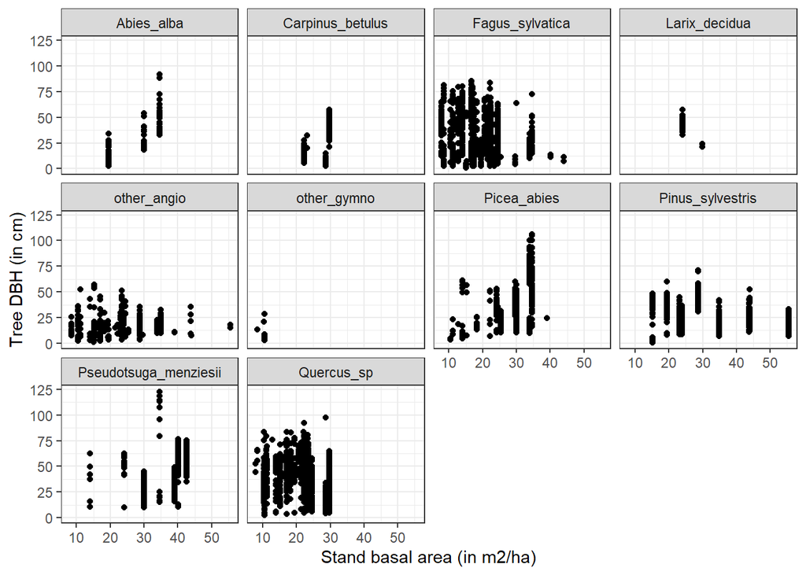

## Crown allometries

### Tree height

```
## [1] "Fit for angiosperm..."
## [1] "Fit for gymnosperm..."
```

```
##    phylogeny       b1         b2       b3
## 1 angiosperm 29.06818 0.04515920 1.181335
## 2 gymnosperm 53.10561 0.01982163 1.069503
```

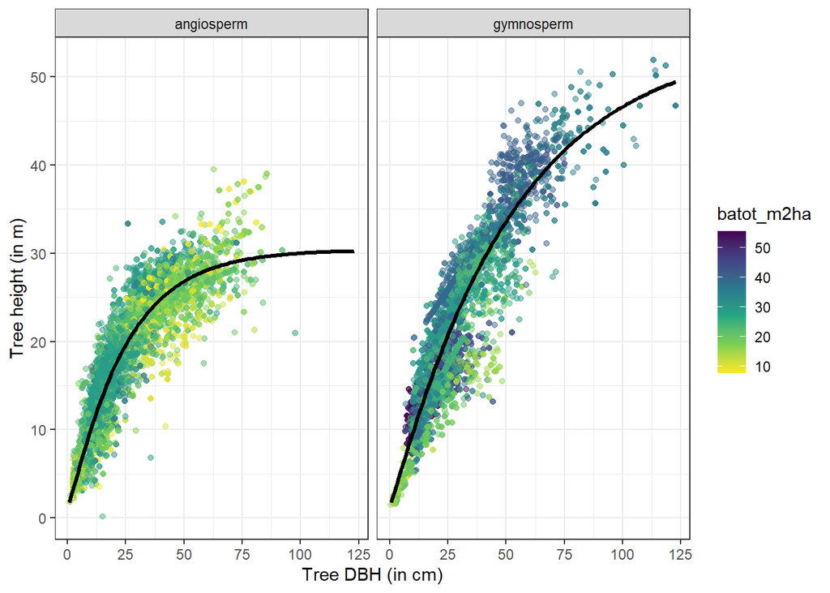

### Crown base height

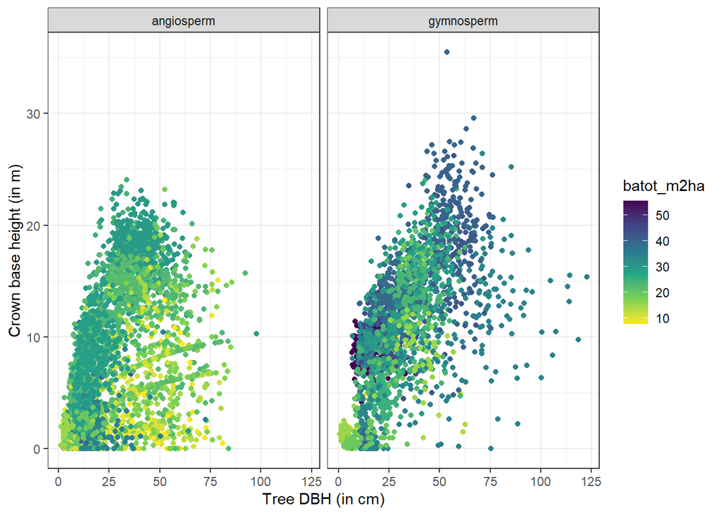

### Crown depth

```
## [1] "Fit for angiosperm..."
## [1] "Fit for gymnosperm..."
```

```
##    phylogeny        a1        a2           a3
## 1 angiosperm 2.8767219 0.5251251 -0.041617871
## 2 gymnosperm 0.8636401 0.8052536 -0.002417362
```

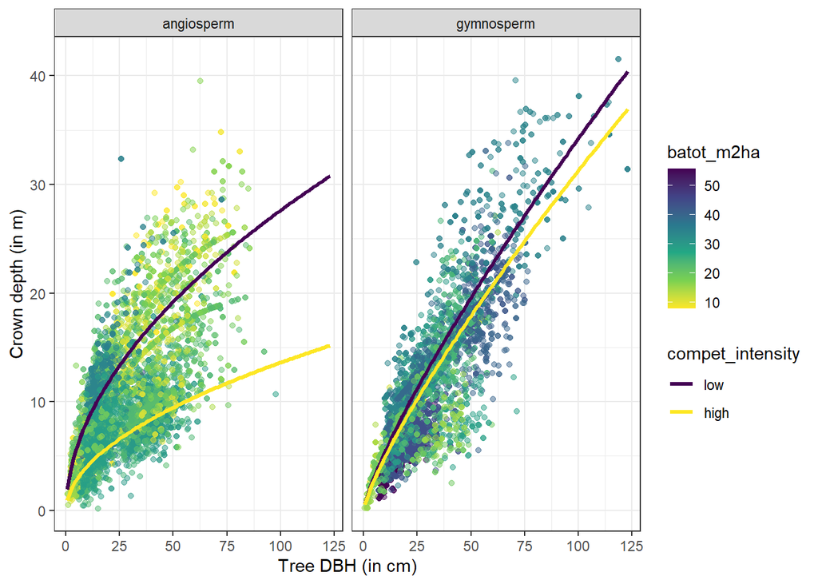

### Mean crown radius

```
## [1] "Fit for angiosperm..."
##               Model df      AIC      BIC    logLik   Test  L.Ratio p-value
## mod_no_compet     1  3 14710.50 14730.77 -7352.250
## mod_compet        2  4 14632.37 14659.40 -7312.186 1 vs 2 80.12869  <.0001
## [1] "Fit for gymnosperm..."
##               Model df      AIC      BIC    logLik   Test  L.Ratio p-value
## mod_no_compet     1  3 8963.405 8983.546 -4478.703
## mod_compet        2  4 8951.687 8978.542 -4471.844 1 vs 2 13.71785   2e-04
```

```
##    phylogeny        a1        a2           a3
## 1 angiosperm 0.7125780 0.5129704 -0.002338096
## 2 gymnosperm 0.2929209 0.6572653 -0.000298340
```

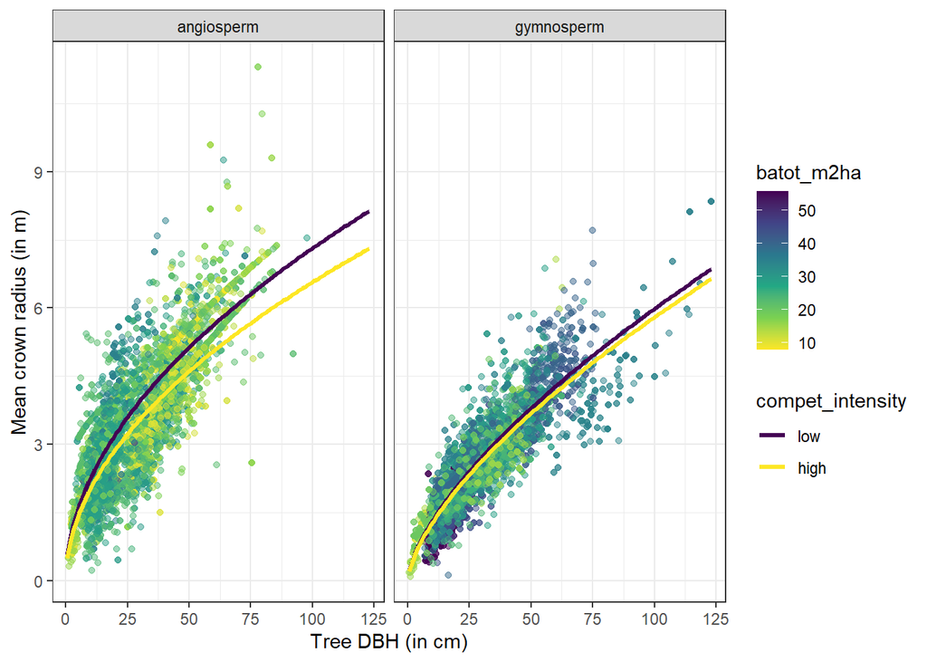

### Consequent crown volume

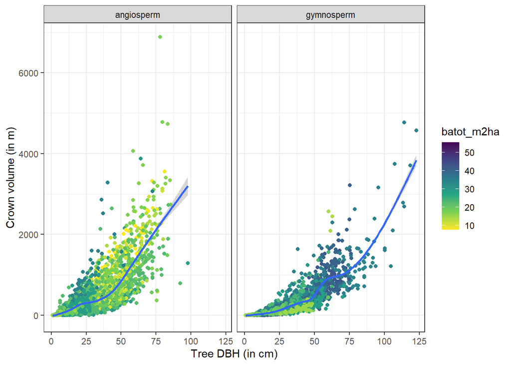